# Lab 3

Eric Miao, Sabrina Peng, Fernando Vazquez

CS7324, Fall 2020

## 1. Business Understanding

### 1.1. Dataset Introduction and Description

Obesity is a medical issue where excessive amounts of body fat result in increased risk of diseases and health problems, including but not limited to heart disease, diabetes, and high blood pressure [[1](https://www.mayoclinic.org/diseases-conditions/obesity/symptoms-causes/syc-20375742#:~:text=Obesity%20is%20a%20complex%20disease,blood%20pressure%20and%20certain%20cancers)]. Worldwide obesity has nearly tripled since 1975, and most of the world's population lives in countries where being overweight or obese kills more people than being underweight - it's not just a first-world country problem anymore [[2](https://www.who.int/news-room/fact-sheets/detail/obesity-and-overweight)]. The rise of this problem can be attributed to a variety of trends, including increasing use of technology while sedentary, less time spent on physical activities, and increased intake of foods that are high in fat and sugar. Although there have been some programs that encourage healthy living to stave off obesity (Michelle Obama's `Let's Move!` campaign comes to mind), obesity often gets much less attention and resources than other acute and chronic diseases.

The dataset we picked for our logistic regression extension task contains data for estimation of obesity levels in individuals from the countries of Mexico, Peru, and Colombia, based on collected information on eating habits, lifestyle choices, and physical characteristics [[3](https://archive.ics.uci.edu/ml/datasets/Estimation+of+obesity+levels+based+on+eating+habits+and+physical+condition+)]. This information was collected via an online survey and preprocessed to handle missing and atypical data. There were 485 initial responses, and respondents were labelled with one of 7 weight categories (`Underweight`, `Normal`, `Overweight I`, `Overweight II`, `Obesity I`, `Obesity II`, and `Obesity III`) based on WHO standards of BMI and Mexican normativity, using the equation below.

\begin{equation*} BMI = \frac{weight}{height^2} \end{equation*}

Interestingly, through the 485 initial responses, the researchers collecting the data discovered the dataset was extremely imbalanced (with a majority of the respondents falling into the normal category), so they decided to generate synthetic data (77% of the final dataset) using the `Weka`) data mining tool and `SMOTE` (synthetic minority over-sampling technique). After using this technique, a more balanced distribution was achieved. Therefore, much of the data processing was already handled for us by the researchers, and we started off with a relatively even dataset (as we will see below) [[4](https://www.sciencedirect.com/science/article/pii/S2352340919306985?via%3Dihub)].

### 1.2. Dataset Significance

A model that can categorize patients into different weight categories based on lifestyle factors can be a very powerful tool in aiding doctors in considering more than just body mass index as a function of obesity. Specifically, there are so many different factors that can affect height and weight, and building in contextual evidence of physical activity and conscious food choices can give doctors a better sense of the overall picture. In addition, healthcare can be extremely expensive, especially in countries without universal healthcare or countries without adequate medical personnel and resources. Collecting basic information via a survey and running it through a model can give people without the ability to see a doctor in person a better sense of where they are on the weight spectrum, and perhaps this model can be paired with a recommender system to give advice on ways to either gain or reduce weight.

Implications of using models to predict obesity arise when medical data is dispensed to real patients based on model output, with no other contextual knowledge (i.e. from a doctor). Though there has been a rise in medical technology in the last few decades (think robot surgeons, etc.), there is a reason why doctors discourage using the Internet to self-diagnose, and recommend getting professional diagnoses. Labelling someone who is underweight or normal as overweight or obese may lead patients towards unhealthy habits like starvation and eating disorders, and labelling someone who is overweight / obese as underweight / normal may exacerbate his or her weight condition and lead to even worse problems.

Though these are issues to consider, there are also many benefits to a multiclass classification model trained to predict weight category. Your average consumer that might use the model to get a weight classification in the absence of professional help, which would require a deployed model running on a server. It could also be used for offline data analysiss by doctors, hospitals, medical institutions and laboratories, medical school students and researchers, and health organizations such as the CDC and WHO. In addition, organizational bodies such as federal / state / local governments and school districts could utilize these to create policies centered around health and movement in an attempt to lower obesity worldwide.

In order for this model to be effective, it would most likely need a relatively high accuracy (around 80% at least), and the errors must not be egregious (i.e. the model would perform very poorly if it classified someone underweight as in the `Obesity III` category. For that reason, we may consider a different calculation of accuracy that depends on the severity of the error made.

## 2. Data Preprocessing and Exploratory Analysis

### 2.1. Data Preprocessing

Though most of the data has been preprocessed in some form for us via the original researchers, there are some steps that need to be taken to achieve proper variable and final dataset representation.

```python
import pandas as pd
import numpy as np

# load the dataset and view first few rows of training dataset
df = pd.read_csv('ObesityDataSet_raw_and_data_sinthetic.csv')
df.head()
```

|  | Gender | Age | Height | Weight | family_history_with_overweight | FAVC | FCVC | NCP | CAEC | SMOKE | CH2O | SCC | FAF | TUE | CALC | MTRANS | NObeyesdad |
| --- | --- | --- | --- | --- | --- | --- | --- | --- | --- | --- | --- | --- | --- | --- | --- | --- | --- |
| 0 | Female | 21.0 | 1.62 | 64.0 | yes | no | 2.0 | 3.0 | Sometimes | no | 2.0 | no | 0.0 | 1.0 | no | Public_Transportation | Normal_Weight |
| 1 | Female | 21.0 | 1.52 | 56.0 | yes | no | 3.0 | 3.0 | Sometimes | yes | 3.0 | yes | 3.0 | 0.0 | Sometimes | Public_Transportation | Normal_Weight |
| 2 | Male | 23.0 | 1.80 | 77.0 | yes | no | 2.0 | 3.0 | Sometimes | no | 2.0 | no | 2.0 | 1.0 | Frequently | Public_Transportation | Normal_Weight |
| 3 | Male | 27.0 | 1.80 | 87.0 | no | no | 3.0 | 3.0 | Sometimes | no | 2.0 | no | 2.0 | 0.0 | Frequently | Walking | Overweight_Level_I |
| 4 | Male | 22.0 | 1.78 | 89.8 | no | no | 2.0 | 1.0 | Sometimes | no | 2.0 | no | 0.0 | 0.0 | Sometimes | Public_Transportation | Overweight_Level_II |

```python
df.columns
```

```
Index(['Gender', 'Age', 'Height', 'Weight', 'family_history_with_overweight',
       'FAVC', 'FCVC', 'NCP', 'CAEC', 'SMOKE', 'CH2O', 'SCC', 'FAF', 'TUE',
       'CALC', 'MTRANS', 'NObeyesdad'],
      dtype='object')
```

Here is a legend of the different column features collected and present within the dataset:

Food consumption:

- Frequent consumption of high caloric food (FAVC)
- Frequency of consumption of vegetables (FCVC)
- Number of main meals (NCP)
- Consumption of food between meals (CAEC)
- Consumption of water daily (CH20)
- Consumption of alcohol (CALC)

Lifestyle conditions:

- Calories consumption monitoring (SCC)
- Physical activity frequency (FAF)
- Time using technology devices (TUE)
- Transportation used (MTRANS)

Physical characteristics:

- Gender
- Age
- Height
- Weight

References:

- https://www.sciencedirect.com/science/article/pii/S2352340919306985?via%3Dihub

```python
import matplotlib.pyplot as plt
import warnings
warnings.simplefilter('ignore', DeprecationWarning)

import missingno as mn

mn.matrix(df)
plt.show()
```

[output not shown]

The dataset contains no missing data, so no imputation techniques are necessary.

```python
# rename obesity target column
target_variable_name = 'obesity_level'

df.rename(columns={'NObeyesdad': target_variable_name}, inplace=True)
print(df[target_variable_name].unique())
```

```
['Normal_Weight' 'Overweight_Level_I' 'Overweight_Level_II'
 'Obesity_Type_I' 'Insufficient_Weight' 'Obesity_Type_II'
 'Obesity_Type_III']
```

```python
# separate feature and target variable information
X = df[[col for col in df.columns if col != target_variable_name]].copy()
y = df[target_variable_name].copy()

print("X shape: ", X.shape)
print("y shape: ", y.shape)
```

```
X shape:  (2111, 16)
y shape:  (2111,)
```

```python
# separate all numerical and categorical columns
numerical_cols = ['Age', 'Height', 'Weight', 'FCVC', 'NCP', 'CH2O', 'FAF', 'TUE']
categorical_binary_cols = ['family_history_with_overweight', 'FAVC', 'SMOKE', 'SCC']

# includes gender (binary), which would be useful as a one hot-encoded feature
categorical_cols = [col for col in X.columns if col not in numerical_cols + categorical_binary_cols]

# convert binary categorical columns to single column 0-1 features
for col in categorical_binary_cols:
    X[col] = X[col].map({'yes': 1, 'no': 0})

# one-hot-encode other ordinal categorical columns
for col in categorical_cols:
    X = X.join(pd.get_dummies(df[col], prefix=col))
    del X[col]

# convert target variable column values to numerical representation for ease of use later on
y = y.map({
    'Normal_Weight': 0,
    'Overweight_Level_I': 1,
    'Overweight_Level_II': 2,
    'Obesity_Type_I': 3,
    'Obesity_Type_II': 4,
    'Obesity_Type_III': 5,
    'Insufficient_Weight': -1
})

# remove indices => without this, there would be issues with the implementation of steepest gradient descent
y = np.array(list(y))
```

Here, we separated our numeric-type columns, categorical (binary) columns (`yes / no`), and categorical columns with more than 2 answer choices (ex. `yes / no / sometimes`).

The categorical (binary) column values were mapped to boolean values (`yes = 1`, `no = 0`), and the categorical columns with more than 2 answer choices were one hot encoded, resulting in the addition of more features.

The target variable weight categories were also mapped to integer values ranging from -1 for `Insufficient_Weight` (underweight) to 5 for `Obesity_Type_III`. The greater the number, the more obese you are. `Normal_Weight` was set at 0.

```python
from sklearn.model_selection import train_test_split
from sklearn.preprocessing import StandardScaler

X_train, X_test, y_train, y_test = train_test_split(X.copy(), y.copy(), test_size=0.2, random_state=42)

scaler = StandardScaler().fit(X_train[numerical_cols])

X_train[numerical_cols] = scaler.transform(X_train[numerical_cols])
X_test[numerical_cols] = scaler.transform(X_test[numerical_cols])

print("X_train shape: ", X_train.shape)
print("y_train shape: ", y_train.shape)
print("X_test shape: ", X_test.shape)
print("y_test shape: ", y_test.shape)
X_train.head()
```

```
X_train shape:  (1688, 27)
y_train shape:  (1688,)
X_test shape:  (423, 27)
y_test shape:  (423,)
```

|  | Age | Height | Weight | family_history_with_overweight | FAVC | FCVC | NCP | SMOKE | CH2O | SCC | ... | CAEC_no | CALC_Always | CALC_Frequently | CALC_Sometimes | CALC_no | MTRANS_Automobile | MTRANS_Bike | MTRANS_Motorbike | MTRANS_Public_Transportation | MTRANS_Walking |
| --- | --- | --- | --- | --- | --- | --- | --- | --- | --- | --- | --- | --- | --- | --- | --- | --- | --- | --- | --- | --- | --- |
| 162 | -0.532646 | -0.768029 | -1.019413 | 1 | 1 | 1.076717 | 0.401513 | 1 | -0.010142 | 0 | ... | 0 | 0 | 0 | 1 | 0 | 0 | 0 | 0 | 1 | 0 |
| 2001 | -0.544235 | 0.546078 | 1.802127 | 1 | 1 | 1.076717 | 0.401513 | 0 | 1.446428 | 0 | ... | 0 | 0 | 0 | 1 | 0 | 0 | 0 | 0 | 1 | 0 |
| 1435 | -0.239258 | -0.427896 | -0.153398 | 1 | 1 | -2.268694 | -1.700740 | 0 | 1.246128 | 0 | ... | 0 | 0 | 0 | 1 | 0 | 0 | 0 | 0 | 1 | 0 |
| 649 | -0.403229 | -1.217973 | -1.623588 | 0 | 0 | 1.076717 | -1.265210 | 0 | 0.892863 | 0 | ... | 0 | 0 | 0 | 0 | 1 | 0 | 0 | 0 | 1 | 0 |
| 1280 | 0.238722 | 1.179597 | 0.745216 | 1 | 1 | 1.076717 | 0.401513 | 0 | 1.398040 | 0 | ... | 0 | 0 | 0 | 1 | 0 | 0 | 0 | 0 | 1 | 0 |

5 rows × 27 columns

Before we normalized our numeric-type column values with scikit-learn's `StandardScaler`, we split our dataset into a training dataset (80% of the data) and testing dataset (20% of the dataset). This is done so that we can scale based on just our training data in order to avoid any data snooping and information from the test dataset leaking into the data for training.

After scaling, we have our final dataset, which has been split into our training dataset `X_train` and `y_train`, and our testing dataset `X_test` and `y_test`. Since our overall dataset is smaller (with just over 2000 instances), we keep all 27 features, as all personal information collected from the survey is relevant to lifestyle choices that may affect obesity status.

### 2.1.1. PCA Analysis

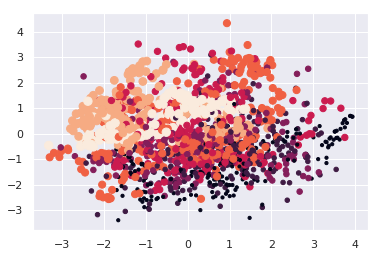

```python
from sklearn.decomposition import PCA
import seaborn as sns
from matplotlib.pyplot import scatter

# do some quick PCA analysis
pca = PCA(n_components=2)
pca.fit(X_train)
X_pca = pca.transform(X_train)

cmap = sns.set(style="darkgrid")
ax = scatter(X_pca[:,0], X_pca[:,1], c=y_train, s=(y_train+2)*10, cmap=cmap)
```

From a two-component PCA, we can see that there is hope of the different categories being separable (at least, with the first two principal components plotted). Below is a breakdown of how the PCA components are related with the different features available for analysis.

```python
pd.DataFrame(pca.components_, columns=X_train.columns, index = ['PC1','PC2'])
```

|  | Age | Height | Weight | family_history_with_overweight | FAVC | FCVC | NCP | SMOKE | CH2O | SCC | ... | CAEC_no | CALC_Always | CALC_Frequently | CALC_Sometimes | CALC_no | MTRANS_Automobile | MTRANS_Bike | MTRANS_Motorbike | MTRANS_Public_Transportation | MTRANS_Walking |
| --- | --- | --- | --- | --- | --- | --- | --- | --- | --- | --- | --- | --- | --- | --- | --- | --- | --- | --- | --- | --- | --- |
| PC1 | -0.060185 | -0.609649 | -0.494501 | -0.107147 | -0.048402 | -0.065608 | -0.302751 | -0.005083 | -0.325155 | 0.022334 | ... | 0.010225 | 0.000310 | -0.002355 | -0.069769 | 0.071813 | -0.027791 | -0.001035 | 0.000519 | 0.028653 | -0.000346 |
| PC2 | 0.633681 | -0.093469 | 0.319416 | 0.075996 | 0.027387 | 0.183748 | -0.116465 | 0.006850 | -0.065232 | -0.020410 | ... | -0.004762 | -0.000631 | -0.002470 | 0.067797 | -0.064695 | 0.145169 | 0.000142 | 0.001060 | -0.129505 | -0.016867 |

2 rows × 27 columns

```python
import plotly
from plotly.graph_objs import Bar, Line
from plotly.graph_objs import Scatter, Layout
from plotly.graph_objs.scatter import Marker
from plotly.graph_objs.layout import XAxis, YAxis
plotly.offline.init_notebook_mode() # run at the start of every notebook

def plot_explained_variance(pca):
    explained_var = pca.explained_variance_ratio_
    cum_var_exp = np.cumsum(explained_var)

    plotly.offline.iplot({
        "data": [Bar(y=explained_var, name='individual explained variance'),
                 Scatter(y=cum_var_exp, name='cumulative explained variance')
            ],
        "layout": Layout(xaxis=XAxis(title='Principal components'), yaxis=YAxis(title='Explained variance ratio'))
    })

pca = PCA(n_components=10)
pca.fit(X_train)
X_pca = pca.transform(X_train)
plot_explained_variance(pca)
```

[interactive chart not shown]

This explained variance graph shows that 80% of the variance in our data can be explained by six principal components. If we were to use PCA, we would use the first six principal components as added features for analysis.

### 2.2. Train / Test Split Discussion

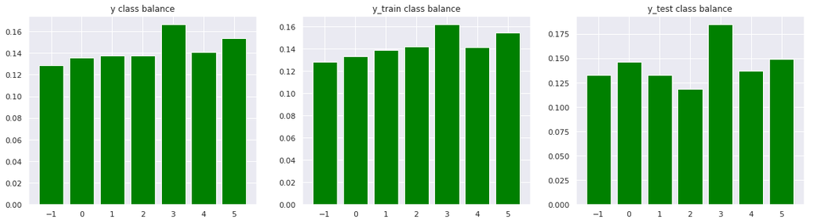

```python
fig = plt.figure(figsize=(20,5))

# check for imbalance in entire dataset
plt.subplot(1, 3, 1)
y_unique_elements, y_counts_elements = np.unique(y, return_counts=True)
plt.title("y class balance")
plt.bar(y_unique_elements, y_counts_elements / sum(y_counts_elements), color='green')

# check for imbalance in training dataset
plt.subplot(1, 3, 2)
ytrain_unique_elements, ytrain_counts_elements = np.unique(y_train, return_counts=True)
plt.title("y_train class balance")
plt.bar(ytrain_unique_elements, ytrain_counts_elements / sum(ytrain_counts_elements), color='green')

# check for imbalance in testing dataset
plt.subplot(1, 3, 3)
ytest_unique_elements, ytest_counts_elements = np.unique(y_test, return_counts=True)
plt.title("y_test class balance")
plt.bar(ytest_unique_elements, ytest_counts_elements / sum(ytest_counts_elements), color='green')

plt.show()
```

One thing to look out for when utilizing machine learning models in classification tasks is whether or not the dataset is imbalanced - if the number of instances of one class is very small or large in comparison to other classes. In the case of our multi-class classification task, the number of samples present in the dataset of each class is relatively balanced, with each category taking up between 12% - 16% of the final dataset. This is because this dataset was augmented from the original survey data (around 23% of the final dataset) to what it is now in order to rectify class imbalance.

The data is still balanced after splitting into an 80/20 test dataset, which is ideal for our logistic regression modelling. This means that our 80/20 is appropriate for our dataset.

## 3. Modeling

### 3.1. Binary Logistic Regression

Code taken from [CS 7324 logistic regression notebook](https://github.com/eclarson/MachineLearningNotebooks/blob/master/05.%20Logistic%20Regression.ipynb).

```python
import numpy as np
from scipy.special import expit

class BinaryLogisticRegressionBase:
    # private:
    def __init__(self, eta=0.01, iterations=20):
        self.eta = eta
        self.iters = iterations
        # internally we will store the weights as self.w_ to keep with sklearn conventions

    def __str__(self):
        return 'Base Binary Logistic Regression Object, Not Trainable'

    # convenience, private and static:
    @staticmethod
    def _sigmoid(theta):
        # increase stability, redefine sigmoid operation
        return expit(theta) #1/(1+np.exp(-theta))

    @staticmethod
    def _add_bias(X):
        return np.hstack((np.ones((X.shape[0],1)),X)) # add bias term

    # public:
    def predict_proba(self, X, add_bias=True):
        # add bias term if requested
        Xb = self._add_bias(X) if add_bias else X
        return self._sigmoid(Xb @ self.w_) # return the probability y=1

    def predict(self,X):
        return (self.predict_proba(X)>0.5) #return the actual prediction
```

```python
# inherit from base class
class BinaryLogisticRegression(BinaryLogisticRegressionBase):
    #private:
    def __str__(self):
        if(hasattr(self,'w_')):
            return 'Binary Logistic Regression Object with coefficients:\n'+ str(self.w_) # is we have trained the object
        else:
            return 'Untrained Binary Logistic Regression Object'

    def _get_gradient(self,X,y):
        ydiff = y-self.predict_proba(X,add_bias=False).ravel() # get y difference
        gradient = np.mean(X * ydiff[:,np.newaxis], axis=0) # make ydiff a column vector and multiply through

        return gradient.reshape(self.w_.shape)

    # public:
    def fit(self, X, y):
        Xb = self._add_bias(X) # add bias term
        num_samples, num_features = Xb.shape

        self.w_ = np.zeros((num_features,1)) # init weight vector to zeros

        # for as many as the max iterations
        for _ in range(self.iters):
            gradient = self._get_gradient(Xb,y)
            self.w_ += gradient*self.eta # multiply by learning rate
```

```python
class LogisticRegression:
    def __init__(self, eta=0.01, iterations=20):
        self.eta = eta
        self.iters = iterations
        # internally we will store the weights as self.w_ to keep with sklearn conventions

    def __str__(self):
        if(hasattr(self,'w_')):
            return 'MultiClass Logistic Regression Object with coefficients:\n'+ str(self.w_) # is we have trained the object
        else:
            return 'Untrained MultiClass Logistic Regression Object'

    def fit(self,X,y):
        num_samples, num_features = X.shape
        self.unique_ = np.unique(y) # get each unique class value
        num_unique_classes = len(self.unique_)
        self.classifiers_ = [] # will fill this array with binary classifiers

        for i,yval in enumerate(self.unique_): # for each unique value
            y_binary = (y==yval) # create a binary problem
            # train the binary classifier for this class
            blr = BinaryLogisticRegression(self.eta, self.iters)
            blr.fit(X,y_binary)
            # add the trained classifier to the list
            self.classifiers_.append(blr)

        # save all the weights into one matrix, separate column for each class
        self.w_ = np.hstack([x.w_ for x in self.classifiers_]).T

    def predict_proba(self,X):
        probs = []
        for blr in self.classifiers_:
            probs.append(blr.predict_proba(X)) # get probability for each classifier

        return np.hstack(probs) # make into single matrix

    def predict(self,X):
        return self.unique_[np.argmax(self.predict_proba(X),axis=1)] # take argmax along row
```

```python
from sklearn.metrics import accuracy_score

params = dict(eta=0.1, iterations=500)
lr = LogisticRegression(**params)
lr.fit(X_train, y_train)
yhat = lr.predict(X_test)
print('Accuracy of: ', accuracy_score(y_test, yhat))
```

```
Accuracy of:  0.6619385342789598
```

```python
import random
from numpy.linalg import pinv

class OptimizedBinaryLogisticRegression(BinaryLogisticRegression):
    # extend init functions
    def __init__(self, optimization='sd', **kwds):
        # need to add to the original initializer
        self.optimization = optimization
        # but keep other keywords
        super().__init__(**kwds) # call parent initializer

    # completely overload gradient function
    def _get_gradient(self,X,y):
        # programming \sum_i (yi-g(xi))xi
        if self.optimization == "sd":
            return self._opt_steepest_descent(X,y); # this is also the default
        elif self.optimization == "sgd":
            return self._opt_stochastic_descent(X,y);
        elif self.optimization == "newton":
            return self._opt_newtons_method(X,y);

    def _opt_steepest_descent(self,X,y):
        ydiff = y-self.predict_proba(X,add_bias=False).ravel() # get y difference
        gradient = np.mean(X * ydiff[:,np.newaxis], axis=0) # make ydiff a column vector and multiply through
        gradient = gradient.reshape(self.w_.shape)
        return gradient

    def _opt_stochastic_descent(self,X,y):
        idx = int(np.random.rand()*len(y)) # grab random instance
        ydiff = y[idx]-self.predict_proba(X[idx],add_bias=False) # get y difference (now scalar)
        gradient = X[idx] * ydiff[:,np.newaxis] # make ydiff a column vector and multiply through
        gradient = gradient.reshape(self.w_.shape)
        return gradient

    def _opt_newtons_method(self,X,y):
        g = self.predict_proba(X,add_bias=False).ravel() # get sigmoid value for all classes
        hessian = X.T @ np.diag(g*(1-g)) @ X - 2 * 0 # calculate the hessian
        ydiff = y-g # get y difference
        gradient = np.sum(X * ydiff[:,np.newaxis], axis=0) # make ydiff a column vector and multiply through
        gradient = gradient.reshape(self.w_.shape)
        return pinv(hessian) @ gradient #need to import pinv
```

```python
# now redefine the Logistic Regression Function where needed
class OptimizedLogisticRegression(LogisticRegression):
    def __init__(self, optimization='sd', **kwds):
        # need to add to the original initializer
        self.optimization = optimization
        # but keep other keywords
        super().__init__(**kwds) # call parent initializer

    def fit(self,X,y):
        num_samples, num_features = X.shape
        self.unique_ = np.unique(y) # get each unique class value
        num_unique_classes = len(self.unique_)
        self.classifiers_ = [] # will fill this array with binary classifiers

        for i,yval in enumerate(self.unique_): # for each unique value
            y_binary = y==yval # create a binary problem
            # train the binary classifier for this class
            blr = OptimizedBinaryLogisticRegression(eta=self.eta,
                                                    iterations=self.iters,
                                                    optimization=self.optimization)

            blr.fit(X,y_binary)
            # add the trained classifier to the list
            self.classifiers_.append(blr)

        # save all the weights into one matrix, separate column for each class
        self.w_ = np.hstack([x.w_ for x in self.classifiers_]).T
```

```python
%%time

# optimization only
params = dict(eta=0.1, iterations=500, optimization='sd')
lr = OptimizedLogisticRegression(**params)

lr.fit(X_train, y_train)
yhat = lr.predict(X_test)
print('Accuracy of: ', accuracy_score(y_test, yhat))
```

```
Accuracy of:  0.6619385342789598
CPU times: user 530 ms, sys: 0 ns, total: 530 ms
Wall time: 530 ms
```

```python
class OptimizedRegularizedBinaryLogisticRegression(OptimizedBinaryLogisticRegression):
    # extend init functions
    def __init__(self, regularization='l2', C=0.0, **kwds):
        # need to add to the original initializer
        self.regularization = regularization
        self.C = C
        # but keep other keywords
        super().__init__(**kwds) # call parent initializer


    # extend previous class to change functionality
    def _get_gradient(self,X,y):
        # call get gradient from previous class
        gradient = super()._get_gradient(X,y)

        # add in l1, l2, or l1 + l2 regularization (to all except bias term)
        if self.regularization == 'l2':
            gradient[1:] += (-2 * self.w_[1:] * self.C)
        elif self.regularization == 'l1':
            gradient[1:] += (-1 * np.sign(self.w_[1:]) * self.C)
        elif self.regularization == 'both':
            l2_adj = (-2 * self.w_[1:] * self.C)
            l1_adj = (-1 * np.sign(self.w_[1:]) * self.C)
            gradient[1:] += (l2_adj + l1_adj)

        return gradient
```

```python
# now redefine the Logistic Regression Function where needed
class OptimizedRegularizedLogisticRegression(OptimizedLogisticRegression):
    def __init__(self, regularization='l2', C=0.0, **kwds):
        # need to add to the original initializer
        self.regularization = regularization
        self.C = C
        # but keep other keywords
        super().__init__(**kwds) # call parent initializer

    def fit(self,X,y):
        num_samples, num_features = X.shape
        self.unique_ = np.unique(y) # get each unique class value
        num_unique_classes = len(self.unique_)
        self.classifiers_ = [] # will fill this array with binary classifiers

        for i,yval in enumerate(self.unique_): # for each unique value
            y_binary = y==yval # create a binary problem
            # train the binary classifier for this class
            blr = OptimizedRegularizedBinaryLogisticRegression(eta=self.eta,
                                                               iterations=self.iters,
                                                               optimization=self.optimization,
                                                               regularization=self.regularization,
                                                               C=self.C)
            blr.fit(X,y_binary)
            # add the trained classifier to the list
            self.classifiers_.append(blr)

        # save all the weights into one matrix, separate column for each class
        self.w_ = np.hstack([x.w_ for x in self.classifiers_]).T
```

```python
%%time

# optimization and regularization
params = dict(eta=0.1, iterations=500, optimization='sd', regularization='l1', C=0.001)
lr = OptimizedRegularizedLogisticRegression(**params)
lr.fit(X_train, y_train)
yhat = lr.predict(X_test)
print('Accuracy of: ', accuracy_score(y_test, yhat))
```

```
Accuracy of:  0.6690307328605201
CPU times: user 589 ms, sys: 0 ns, total: 589 ms
Wall time: 589 ms
```

### 3.2 Training Classifier (Hyperparameter Tuning)

Now, we take a look at the performance of our model with different hyperparameters to choose our best-performing model (with an evaluation metric of accuracy).

Resources used:

- https://www.jeremyjordan.me/hyperparameter-tuning/

```python
# this may take a while (Newton's, specifically)
import time

optimization_vals = ['sd', 'sgd', 'newton']
regularization_vals = ['none', 'l1', 'l2', 'both']
C_vals = [1, 0.1, 0.01, 0.001] # reasonable lambda values typically range between 0 and 0.1

grid_search_results = {}
for opt in optimization_vals:
    for reg in regularization_vals:
        for C in C_vals:
            technique = str(opt) + '_' + str(reg) + '_' + str(C)
            params = dict(eta=0.1, iterations=500, optimization=opt, regularization=reg, C=C)

            start_time = time.time()
            lr = OptimizedRegularizedLogisticRegression(**params)
            lr.fit(X_train, y_train)
            yhat = lr.predict(X_test)
            end_time = time.time()

            accuracy = accuracy_score(y_test, yhat)
            time_elapsed = end_time - start_time
            print(f'{technique}: {accuracy} accuracy, {time_elapsed} s', )

            grid_search_results[technique] = (accuracy, time_elapsed)
```

```
sd_none_1: 0.6619385342789598 accuracy, 0.5400152206420898 s
sd_none_0.1: 0.6619385342789598 accuracy, 0.5406894683837891 s
sd_none_0.01: 0.6619385342789598 accuracy, 0.541391134262085 s
sd_none_0.001: 0.6619385342789598 accuracy, 0.5383059978485107 s
sd_l1_1: 0.20803782505910165 accuracy, 0.5646936893463135 s
sd_l1_0.1: 0.4160756501182033 accuracy, 0.5619540214538574 s
sd_l1_0.01: 0.6453900709219859 accuracy, 0.5618875026702881 s
sd_l1_0.001: 0.6690307328605201 accuracy, 0.5630989074707031 s
sd_l2_1: 0.3664302600472813 accuracy, 0.5606248378753662 s
sd_l2_0.1: 0.5839243498817966 accuracy, 0.5584840774536133 s
sd_l2_0.01: 0.6548463356973995 accuracy, 0.5601816177368164 s
sd_l2_0.001: 0.6619385342789598 accuracy, 0.5631451606750488 s
sd_both_1: 0.23404255319148937 accuracy, 0.5782041549682617 s
sd_both_0.1: 0.3947990543735225 accuracy, 0.5761058330535889 s
sd_both_0.01: 0.6170212765957447 accuracy, 0.5751769542694092 s
sd_both_0.001: 0.6643026004728132 accuracy, 0.5738968849182129 s
sgd_none_1: 0.5862884160756501 accuracy, 0.05250144004821777 s
sgd_none_0.1: 0.5531914893617021 accuracy, 0.052114009857177734 s
sgd_none_0.01: 0.6052009456264775 accuracy, 0.052396297454833984 s
sgd_none_0.001: 0.5555555555555556 accuracy, 0.05452322959899902 s
sgd_l1_1: 0.20803782505910165 accuracy, 0.07294297218322754 s
sgd_l1_0.1: 0.26004728132387706 accuracy, 0.07197833061218262 s
sgd_l1_0.01: 0.5555555555555556 accuracy, 0.0767068862915039 s
sgd_l1_0.001: 0.5437352245862884 accuracy, 0.08144617080688477 s
sgd_l2_1: 0.30023640661938533 accuracy, 0.07801556587219238 s
sgd_l2_0.1: 0.34515366430260047 accuracy, 0.07815933227539062 s
sgd_l2_0.01: 0.5791962174940898 accuracy, 0.07598996162414551 s
sgd_l2_0.001: 0.5933806146572104 accuracy, 0.07606816291809082 s
sgd_both_1: 0.20803782505910165 accuracy, 0.09478163719177246 s
sgd_both_0.1: 0.3640661938534279 accuracy, 0.08839797973632812 s
sgd_both_0.01: 0.5342789598108747 accuracy, 0.08751177787780762 s
sgd_both_0.001: 0.6146572104018913 accuracy, 0.08789873123168945 s
newton_none_1: 0.7777777777777778 accuracy, 29.76912832260132 s
newton_none_0.1: 0.7777777777777778 accuracy, 30.028927326202393 s
newton_none_0.01: 0.7777777777777778 accuracy, 29.79655408859253 s
newton_none_0.001: 0.7777777777777778 accuracy, 29.570451736450195 s
newton_l1_1: 0.39952718676122934 accuracy, 29.856186866760254 s
newton_l1_0.1: 0.7706855791962175 accuracy, 30.425308227539062 s
newton_l1_0.01: 0.7848699763593381 accuracy, 30.26831817626953 s
newton_l1_0.001: 0.7777777777777778 accuracy, 30.083755016326904 s
newton_l2_1: 0.14657210401891252 accuracy, 29.755975484848022 s
newton_l2_0.1: 0.46099290780141844 accuracy, 30.246934175491333 s
newton_l2_0.01: 0.7754137115839244 accuracy, 30.714311838150024 s
newton_l2_0.001: 0.7777777777777778 accuracy, 30.096146821975708 s
newton_both_1: 0.14657210401891252 accuracy, 30.16749930381775 s
newton_both_0.1: 0.3144208037825059 accuracy, 29.940086603164673 s
newton_both_0.01: 0.7754137115839244 accuracy, 30.058549165725708 s
newton_both_0.001: 0.7777777777777778 accuracy, 30.96601939201355 s
```

```python
# get best performing model by accuracy
models = list(grid_search_results.keys())
accuracies = [accuracy for (accuracy, time) in grid_search_results.values()]
times = [time for (accuracy, time) in grid_search_results.values()]

maxIdx = accuracies.index(max(accuracies))
print(f"Best-performing model: {models[maxIdx]}")
print(f"Accuracy: {accuracies[maxIdx]}")
print(f"Time: {times[maxIdx]} s")
```

```
Best-performing model: newton_l1_0.01
Accuracy: 0.7848699763593381
Time: 30.26831817626953 s
```

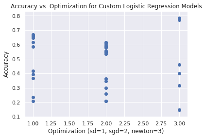

```python
# plot accuracy against optimization values
optimization_dict = dict(sd=1, sgd=2, newton=3)
opt_vals = []
opt_acc = []

for idx, model in enumerate(models):
    val = model.split('_')[0]
    opt_vals.append(optimization_dict[val])
    opt_acc.append(accuracies[idx])

plt.scatter(opt_vals, opt_acc)
plt.title("Accuracy vs. Optimization for Custom Logistic Regression Models")
plt.xlabel("Optimization (sd=1, sgd=2, newton=3)")
plt.ylabel("Accuracy")
plt.show()
```

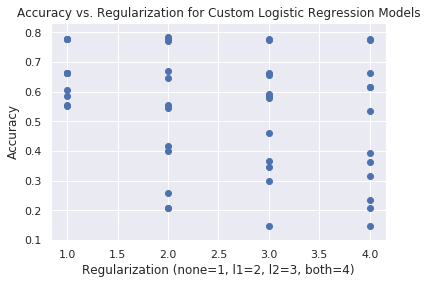

```python
# plot accuracy against regularization values
regularization_dict = dict(none=1, l1=2, l2=3, both=4)
reg_vals = []
reg_acc = []

for idx, model in enumerate(models):
    val = model.split('_')[1]
    reg_vals.append(regularization_dict[val])
    reg_acc.append(accuracies[idx])

plt.scatter(reg_vals, reg_acc)
plt.title("Accuracy vs. Regularization for Custom Logistic Regression Models")
plt.xlabel("Regularization (none=1, l1=2, l2=3, both=4)")
plt.ylabel("Accuracy")
plt.show()
```

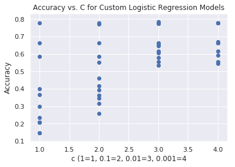

```python
# plot accuracy against regularization values
C_dict = {}
C_dict['1'] = 1
C_dict['0.1'] = 2
C_dict['0.01'] = 3
C_dict['0.001'] = 4

C_vals = []
C_acc = []

for idx, model in enumerate(models):
    val = model.split('_')[2]
    C_vals.append(C_dict[val])
    C_acc.append(accuracies[idx])

plt.scatter(C_vals, C_acc)
plt.title("Accuracy vs. C for Custom Logistic Regression Models")
plt.xlabel("c (1=1, 0.1=2, 0.01=3, 0.001=4")
plt.ylabel("Accuracy")
plt.show()
```

[figure not shown]

```python
# plot accuracy against times
plt.scatter(times, accuracies)
plt.title("Time Elapsed vs Accuracy for Custom Logistic Regression Models")
plt.xlabel('Accuracy')
plt.ylabel('Time (s)')
plt.show()
```

Other hyperparameter tuning methods include random search and Bayesian optimization.

There is definitely data snooping occurring here. Data snooping is essentially conducting statistical inference or making conclusions after looking at the data, whether intential or not. An example of unintentional data snooping would be scaling `X_train` using a StandardScaler that is fit on the entire `X` data. This is because we would be giving the model an advantage, as the features it will use to train and test will include information about `X_test`.

Though we are not committing the above example of data snooping, we ARE committing data snooping via hyperparameter tuning using the evaluation (accuracy) results of our model on the test data. Choosing `newton`, `l1`, and `0.01` as our `optimization`, `regularization`, and `C` values, respectively, came from selecting the model with the highest accuracy on our test data. This means that any further training that we do with our "best" model and parameters is polluted by our model's knowledge of the test dataset. This also defeats the purpose of our model, which is to be able to generalize to completely unseen instances.

To avoid this data leakage, we should split the dataset into a training set, a validation set, and a testing set (for example, using a 70/15/15 split between the three categories). The validation set allows us to perform hyperparameter tuning without touching the testing set, which we can then use to evaluate the overall performance of hte model on unseen data. A more advanced method of this is k-fold cross validation [[ref](https://www.jeremyjordan.me/hyperparameter-tuning/)].

### 3.3 Performance Comparison

```python
# run our best model
params = dict(eta=0.1, iterations=500, optimization='newton', regularization='l1', C=0.01)

start_time = time.time()
our_model = OptimizedRegularizedLogisticRegression(**params)
our_model.fit(X_train, y_train)
our_yhat = our_model.predict(X_test)
end_time = time.time()

our_accuracy = accuracy_score(y_test, our_yhat)
our_time_elapsed = end_time - start_time
print(f'{models[maxIdx]}: {our_accuracy} accuracy, {our_time_elapsed} s', )
```

```
newton_l1_0.01: 0.7848699763593381 accuracy, 30.018269300460815 s
```

```python
# run scikit-learn's logistic regression model

from sklearn import metrics
from sklearn.linear_model import LogisticRegression as SKLogisticRegression

start_time = time.time()
their_model = SKLogisticRegression(max_iter=500, multi_class='ovr', solver='newton-cg', penalty='l2', C=0.01).fit(X_train, y_train)
their_yhat = their_model.predict(X_test)
end_time = time.time()

their_accuracy = accuracy_score(y_test, their_yhat)
their_time_elapsed = end_time - start_time
print(f'scikit-learn Logistic Regression: {their_accuracy} accuracy, {their_time_elapsed} s', )
```

```
scikit-learn Logistic Regression: 0.6312056737588653 accuracy, 0.11408519744873047 s
```

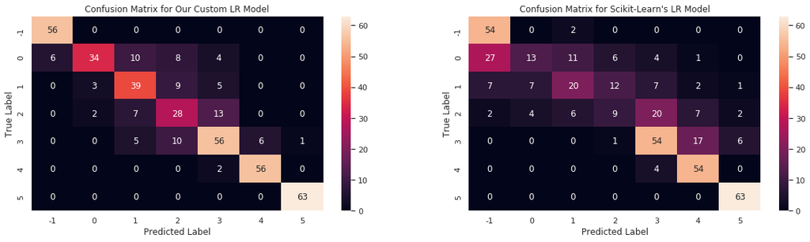

```python
fig = plt.figure(figsize=(20,5))

# plot custom model confusion matrix
plt.subplot(1, 2, 1)
our_cm = metrics.confusion_matrix(y_test, our_yhat)
our_df_cm = pd.DataFrame(our_cm, index = [i for i in range(-1, 6)], columns = [i for i in range(-1, 6)])
sns.heatmap(our_df_cm, annot=True)
plt.title("Confusion Matrix for Our Custom LR Model")
plt.xlabel("Predicted Label")
plt.ylabel("True Label")

# plot scikit-learn model confusion matrix
plt.subplot(1, 2, 2)
their_cm = metrics.confusion_matrix(y_test, their_yhat)
their_df_cm = pd.DataFrame(their_cm, index = [i for i in range(-1, 6)], columns = [i for i in range(-1, 6)])
sns.heatmap(their_df_cm, annot=True)

plt.title("Confusion Matrix for Scikit-Learn's LR Model")
plt.xlabel("Predicted Label")
plt.ylabel("True Label")
plt.show()
```

```
scikit-learn Better Logistic Regression: 0.8699763593380615 accuracy, 0.2821316719055176 s
```

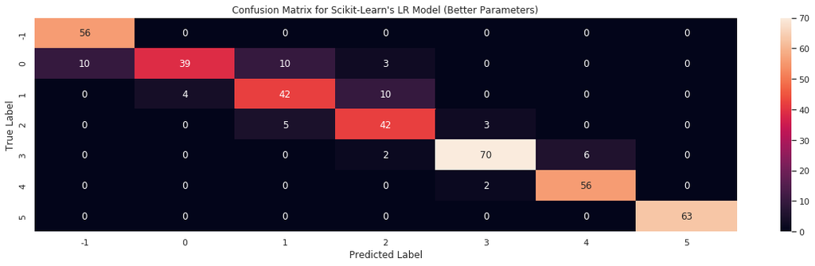

```python
# find a better logistic regression parameter space in scikit-learn
fig = plt.figure(figsize=(20,5))

start_time = time.time()
their_better_model = SKLogisticRegression(max_iter=500).fit(X_train, y_train)
their_better_yhat = their_better_model.predict(X_test)
end_time = time.time()

their_better_accuracy = accuracy_score(y_test, their_better_yhat)
their_better_time_elapsed = end_time - start_time
print(f'scikit-learn Better Logistic Regression: {their_better_accuracy} accuracy, {their_better_time_elapsed} s', )

plt.subplot(1, 1, 1)
their_better_cm = metrics.confusion_matrix(y_test, their_better_yhat)
their_better_df_cm = pd.DataFrame(their_better_cm, index = [i for i in range(-1, 6)], columns = [i for i in range(-1, 6)])
sns.heatmap(their_better_df_cm, annot=True)

plt.title("Confusion Matrix for Scikit-Learn's LR Model (Better Parameters)")
plt.xlabel("Predicted Label")
plt.ylabel("True Label")
plt.show()
```

In this section, we compare our best custom model (`newton`, `l1`, and `0.01`) to a comparable model from scikit-learn's implementation of logistic regression. The closest comparable model we could get for scikit-learn was using `newton-cg` and `l2` regularization, since `l1` regularization is not available with the `newton-cg` solver method.

Interestingly, as you can see from the accuracies and confusion matrices, scikit-learn's implementation with similar tuned hyperparameters gives us a lower accuracy (by about 15%, which is non-trivial) and more misclassification errors. However, the scikit-learn implementation runs about 265 times faster, at under a second compared to 30 seconds. Luckily, for both the custom model and the scikit-learn model, the classification errors are not egregious - most of them are errors either up 1/2 weight categories or down 1/2 weight categories, which means the model is generally avoiding errors of >=3 weight categories.

In order to see if another set of hyperparameters would work better for the scikit-learn model's performance, we use the default logistic regression parameters (a penalty of `l2`, a C of `1.0`, and a solver of `lbfgs`). This gives us a much better accuracy of `0.87` (which beats the other scikit-learn model by about 24%), and although the procedure takes longer (about 3x the amount of time), the task still completes in under a second, at around 0.3 seconds instead of 0.1 seconds.

Therefore, we can conclude that scikit-learn's implementation is much faster than our custom logistic regression implementation. The library's implementation *can* achieve better performance in terms of accuracy, but we should alos complete some sort of hyperparameter tuning using scikit-learn's implementation in order to find the best model, as we can see that certain combinations of parameters can achieve suboptimal results.

## 4. Deployment

We would recommend the scikit-learn implementation for a deployed machine learning model to be used in the real world. The scikit-learn library has proved that with certain combinations of hyperparameters that it can achieve both a better accuracy (evaluation metric) and speed performance (in seconds) than our custom logistic regression model. Though the scikit-learn library may contain a lot more source code than our implementation, the possibility of going from a maximum of 78% accuracy to 87% accuracy (which is a non-trivial increase in performance, and may possibly be even higher once hyperparameter tuning is completed) is worth the extra overhead / storage space needed. In addition, the steepest descent and stochastic gradient descent methods for our custom logistic regression model performed much more poorly than Newton's method, but Newton's method required a huge tradeoff in terms of needing a time increase of great magnitude to complete. The library's improvement over our implementation in terms of time is not as important, as the model does not have to be redeployed and retrained very often, but the accuracy increase is significant.

In conclusion, in order to be able to categorize people into weight categories based on lifestyle choices and physical characteristics, accuracy must be as high as possible to avoid giving out faulty medical information or advice, so we would advise that the scikit-learn implementation be used in a real world deployment situation.

## 5. Mean Squared Error as Objective Function

```python
class MSEBinaryLogisticRegressionBase:
    # private:
    def __init__(self, eta=0.01, iterations=20):
        self.eta = eta
        self.iters = iterations
        # internally we will store the weights as self.w_ to keep with sklearn conventions

    def __str__(self):
        return 'Base Binary Logistic Regression Object, Not Trainable'

    # convenience, private and static:
    @staticmethod
    def _sigmoid(theta):
        # increase stability, redefine sigmoid operation
        return expit(theta) #1/(1+np.exp(-theta))

    @staticmethod
    def _add_bias(X):
        return np.hstack((np.ones((X.shape[0],1)),X)) # add bias term

    # public:
    def predict_proba(self, X, add_bias=True):
        # add bias term if requested
        Xb = self._add_bias(X) if add_bias else X
        return self._sigmoid(Xb @ self.w_) # return the probability y=1

    def predict(self,X):
        return (self.predict_proba(X)>0.5) #return the actual prediction
```

```python
# inherit from base class
class MSEBinaryLogisticRegression(MSEBinaryLogisticRegressionBase):
    #private:
    def __str__(self):
        if(hasattr(self,'w_')):
            return 'Binary Logistic Regression Object with coefficients:\n'+ str(self.w_) # is we have trained the object
        else:
            return 'Untrained Binary Logistic Regression Object'

    def _get_gradient(self,X,y):
        g = self.predict_proba(X,add_bias=False).ravel() # get sigmoid value for all classes
        hessian = X.T @ np.diag(-2*(y-g)*g*(1-g)) @ X # calculate the hessian with the second derivative of the MSE function

        ydiff = y-g # get y difference
        gradient = np.sum(X * ydiff[:,np.newaxis], axis=0) # make ydiff a column vector and multiply through
        gradient = gradient.reshape(self.w_.shape)
        return pinv(hessian) @ gradient #need to import pinv

    # public:
    def fit(self, X, y):
        Xb = self._add_bias(X) # add bias term
        num_samples, num_features = Xb.shape

        self.w_ = np.zeros((num_features, 1)) # init weight vector to zeros

        # for as many as the max iterations
        for _ in range(self.iters):
            gradient = self._get_gradient(Xb,y)
            self.w_ -= gradient * self.eta # multiply by learning rate
```

```python
class MSELogisticRegression:
    def __init__(self, eta=0.01, iterations=20):
        self.eta = eta
        self.iters = iterations
        # internally we will store the weights as self.w_ to keep with sklearn conventions

    def __str__(self):
        if(hasattr(self,'w_')):
            return 'MultiClass Logistic Regression Object with coefficients:\n'+ str(self.w_) # is we have trained the object
        else:
            return 'Untrained MultiClass Logistic Regression Object'

    def fit(self,X,y):
        num_samples, num_features = X.shape
        self.unique_ = np.unique(y) # get each unique class value
        num_unique_classes = len(self.unique_)
        self.classifiers_ = [] # will fill this array with binary classifiers

        for i,yval in enumerate(self.unique_): # for each unique value
            y_binary = (y==yval) # create a binary problem
            # train the binary classifier for this class
            blr = MSEBinaryLogisticRegression(self.eta, self.iters)
            blr.fit(X,y_binary)
            # add the trained classifier to the list
            self.classifiers_.append(blr)

        # save all the weights into one matrix, separate column for each class
        self.w_ = np.hstack([x.w_ for x in self.classifiers_]).T

    def predict_proba(self,X):
        probs = []
        for blr in self.classifiers_:
            probs.append(blr.predict_proba(X)) # get probability for each classifier

        return np.hstack(probs) # make into single matrix

    def predict(self,X):
        return self.unique_[np.argmax(self.predict_proba(X),axis=1)] # take argmax along row
```

```python
# run our best model
import time
params = dict(eta=0.1, iterations=500)

start_time = time.time()
lr = MSELogisticRegression(**params)
lr.fit(X_train, y_train)
yhat = lr.predict(X_test)
end_time = time.time()

our_accuracy = accuracy_score(y_test, yhat)
our_time_elapsed = end_time - start_time
print(f'MSE Logistic Regression: {our_accuracy} accuracy, {our_time_elapsed} s', )
```

```
MSE Logistic Regression: 0.13238770685579196 accuracy, 29.781097412109375 s
```

In this section, we attempted to use the MSE (mean squared error) objective function as the loss function for our logistic regression class.

$$ J(\mathbf{W}) = \sum_k^M (\mathbf{y}^{(k)}-\mathbf{a}^{(L)})^2 $$

To achieve update of our weights in a single step, we must use the Hessian, which can be defined as `H[l(w)]` in the equation below. `l(w)` refers to our objective function.

$$ \mathbf{w} \leftarrow \mathbf{w} + \eta \cdot \underbrace{\mathbf{H}[l(\mathbf{w})]^{-1}}_{\text{inverse Hessian}}\cdot\underbrace{\nabla l(\mathbf{w})}_{\text{gradient}}$$

In class, we used Newton's update method and the Hessian matrix to achieve a convergence to the minimum of our loss function (cross entropy) in one update step. We can do the same with the MSE loss function, since it is quadratic. Below, we can see the second partial derivative gradient for the MSE function, as well as the final Hessian matrix calculation that was used to optimize our MSE logistic regression model to be able to find the minimum of the loss function in 1 step.

$$ \frac{\partial J(\mathbf{W})}{\partial [\mathbf{z}^{(2)}]^{(k)}} = -2\left(\mathbf{y}^{(k)}-{[\mathbf{g}]^{(k)}}\right)*{[\mathbf{g}]^{(k)}}*\left(1-{[\mathbf{g}]^{(k)}}\right) $$$$ \mathbf{w} \leftarrow \mathbf{w} - \eta \cdot \underbrace{\left[\mathbf{X}^T \cdot \text{diag}\left[(\mathbf -2 * {y}^{(k)}-{[\mathbf{g}]^{(k)}}\right)*{[\mathbf{g}]^{(k)}}*\left(1-{[\mathbf{g}]^{(k)}}\right)] \cdot \mathbf{X}\right]^{-1} }_{\text{inverse Hessian}} \cdot \underbrace{\mathbf{X}*y_{diff}}_{\text{gradient}}$$

We were not sure of our mathematical derivations for this MSE task, as we utilized different resources and mathematical formulas from the class notebooks (the Hessian matrix structure from the optimization notebook, as well as the second derivative equations from the neural networks notebook), but we feel like the low accuracy may be an indication that our computations are incorrect.

However, in general, using log loss (minimization of binary cross entropy, or maximization of log likelihood) is preferable to using minimization of the MSE as an objective function [[ref](https://towardsdatascience.com/why-not-mse-as-a-loss-function-for-logistic-regression-589816b5e03c)]. Using MSE results in weak penalties for misclassification in the binary problem, and non-convexity of the MSE function in the context of logistic regression [[ref](https://www.noobtonoob.com/post/mse-after-sigmoid)]. When a loss function is not convex, we are more likely to get stuck at local minima without the help of other optimization techniques such as momentum and Adagrad. Therefore, we prefer using minimization of cross-entropy as our loss function over MSE for logistic regression.